# Exploration of Google Analytics for Google Merchandise Store

- Data: Customer data for GStore (provided on Kaggle)
- Performance: Measured by the percentage of sessions that ended in purchases.
- Main questions:
  - What are the main sources where potential customers come from?
  - How do their performances compare?
- Methodology:
  - Graphs
- Conclusions:
  - Major purchases come from referrals (from mall.googleplex.com)
  - Sessions from social networks and social medias performs poorly.

## Data wrangling and cleaning

- Import the data
- Unfold the columns that contains JSON
- Drop constant columns
- Format the data to correct type (e.g datetime, float, ... etc)
- Fill some NaN values where justified

```python
train_df.head()
```

|  | channelGrouping | date | fullVisitorId | sessionId | socialEngagementType | visitId | visitNumber | visitStartTime | device.browser | device.browserSize | device.browserVersion | device.deviceCategory | device.flashVersion | device.isMobile | device.language | device.mobileDeviceBranding | device.mobileDeviceInfo | device.mobileDeviceMarketingName | device.mobileDeviceModel | device.mobileInputSelector | device.operatingSystem | device.operatingSystemVersion | device.screenColors | device.screenResolution | geoNetwork.city | geoNetwork.cityId | geoNetwork.continent | geoNetwork.country | geoNetwork.latitude | … |
| --- | --- | --- | --- | --- | --- | --- | --- | --- | --- | --- | --- | --- | --- | --- | --- | --- | --- | --- | --- | --- | --- | --- | --- | --- | --- | --- | --- | --- | --- | --- |
| 0 | Organic Search | 20160902 | 1131660440785968503 | 1131660440785968503_1472830385 | Not Socially Engaged | 1472830385 | 1 | 1472830385 | Chrome | not available in demo dataset | not available in demo dataset | desktop | not available in demo dataset | False | not available in demo dataset | not available in demo dataset | not available in demo dataset | not available in demo dataset | not available in demo dataset | not available in demo dataset | Windows | not available in demo dataset | not available in demo dataset | not available in demo dataset | Izmir | not available in demo dataset | Asia | Turkey | not available in demo dataset | … |
| 1 | Organic Search | 20160902 | 377306020877927890 | 377306020877927890_1472880147 | Not Socially Engaged | 1472880147 | 1 | 1472880147 | Firefox | not available in demo dataset | not available in demo dataset | desktop | not available in demo dataset | False | not available in demo dataset | not available in demo dataset | not available in demo dataset | not available in demo dataset | not available in demo dataset | not available in demo dataset | Macintosh | not available in demo dataset | not available in demo dataset | not available in demo dataset | not available in demo dataset | not available in demo dataset | Oceania | Australia | not available in demo dataset | … |
| 2 | Organic Search | 20160902 | 3895546263509774583 | 3895546263509774583_1472865386 | Not Socially Engaged | 1472865386 | 1 | 1472865386 | Chrome | not available in demo dataset | not available in demo dataset | desktop | not available in demo dataset | False | not available in demo dataset | not available in demo dataset | not available in demo dataset | not available in demo dataset | not available in demo dataset | not available in demo dataset | Windows | not available in demo dataset | not available in demo dataset | not available in demo dataset | Madrid | not available in demo dataset | Europe | Spain | not available in demo dataset | … |
| 3 | Organic Search | 20160902 | 4763447161404445595 | 4763447161404445595_1472881213 | Not Socially Engaged | 1472881213 | 1 | 1472881213 | UC Browser | not available in demo dataset | not available in demo dataset | desktop | not available in demo dataset | False | not available in demo dataset | not available in demo dataset | not available in demo dataset | not available in demo dataset | not available in demo dataset | not available in demo dataset | Linux | not available in demo dataset | not available in demo dataset | not available in demo dataset | not available in demo dataset | not available in demo dataset | Asia | Indonesia | not available in demo dataset | … |
| 4 | Organic Search | 20160902 | 27294437909732085 | 27294437909732085_1472822600 | Not Socially Engaged | 1472822600 | 2 | 1472822600 | Chrome | not available in demo dataset | not available in demo dataset | mobile | not available in demo dataset | True | not available in demo dataset | not available in demo dataset | not available in demo dataset | not available in demo dataset | not available in demo dataset | not available in demo dataset | Android | not available in demo dataset | not available in demo dataset | not available in demo dataset | not available in demo dataset | not available in demo dataset | Europe | United Kingdom | not available in demo dataset | … |

## How many sessions ended in purchases?

```python
train_df['spent_bool'].value_counts()
```

```
False    892138
True      11515
Name: spent_bool, dtype: int64
```

### Only ~1.3% of sessions end in a purchase

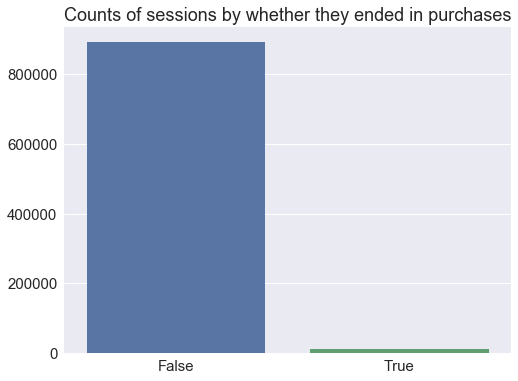

```python
show()
```

## Channel Grouping:

- Organic Search, Social, Direct, Referral, Paid Search, Affiliates, Display
  - Direct: direct, not set, none
  - Organic Search: search engine results
  - Social: social network and social media
  - Referral: e.g. through a link on another domain
  - Paid Search: cpc (cost per click), ppc (pay per click), paidsearch
  - Affiliates
  - Display: cpm (Cost-per-thousand impressions), banner

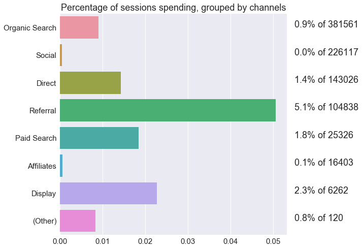

```python
show()
```

### summary

- Sessions coming from social channels very rarely result in purchases.
- Referral sessions have both the highest probability of resulting in a purchase and occupies the largest fraction of the spending sessions.
- Details on Social, Referral, Paid Search, and Display next
- No keyword data nor direct data

### Exploration of referral traffic by site.

- What are the top sites where referrals comes from?
- How well do they convert to sessions that purchase?

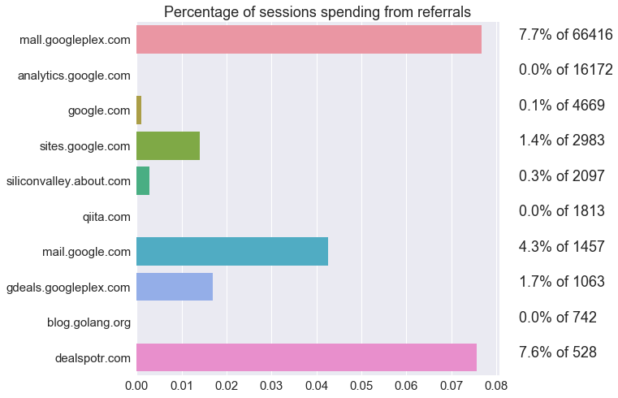

```python
show()
```

### summary

- mall.googleplex.com contributes to most of the referral sessions that end in purchases. (~8%)
- dealspotr.com and gmail worth further exploration.

## Exploration of paid search traffic

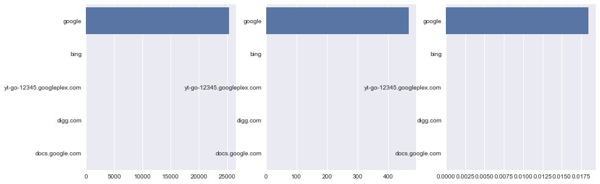

```python
fig, (ax1, ax2, ax3) = plt.subplots(1,3,figsize=(15,5))
sns.barplot(ps_source_c.values, ps_source_c.index, ax = ax1)
sns.barplot(ps_source_p.values, ps_source_p.index, ax = ax2)
sns.barplot(np.divide(ps_source_p.values,ps_source_c.values), ps_source_p.index, ax = ax3)
show()
```

### takeaways:

- All but one cpc paid search come from google. That other one come from Bing.

### Exploration of traffic from display.

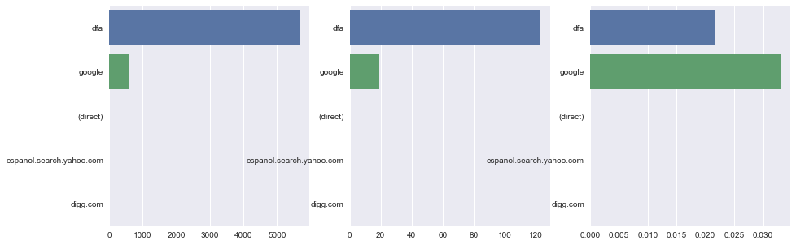

```python
fig, (ax1, ax2, ax3) = plt.subplots(1,3,figsize=(15,5))
sns.barplot(dir_source_c.values, dir_source_c.index, ax = ax1)
sns.barplot(dir_source_p.values, dir_source_p.index, ax = ax2)
sns.barplot(np.divide(dir_source_p.values,dir_source_c.values), dir_source_p.index, ax = ax3)
show()
```

### summary

- dfa (Doubleclick for Advertisers) performs pretty well

### Exploration of traffic from social networks and social media

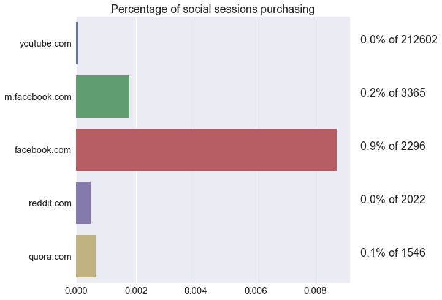

```python
show()
```

### Summary

- Social traffic from youtube very rarely results in purchases. (11 out of 200k, not sure why)
- In general, social networks and social medias don't result in much spending.

## Summary

- Referrals from mall.googleplex.com is the main source of sessions that end in purchases
- Session coming from social networks, especially from youtube, performs poorly
- Paid search and Displayed results performs well compared to organic search/direct traffic

## Suggestions:

- Place more resources into "mall.googleplex.com" site to attract more users from that site.
- Explore promotions through email and dealspotr to increast traffic count.
- Reconsider strategies on ads placed on social media and social networks.